# GEOG 6000 Lab 10 Geostatistics I

Simon Brewer

10/12/2020

In this lab, we will go through the steps of a geostatistical analysis, using a set of precipitation data for Switzerland, and the data set of soil samples from a floodplain near the Meuse river in the Netherlands.

Before starting the lab, you will need to set up a new folder for your working directory. Go to your `geog6000` folder now and create a new folder for today’s class called `lab10`. The following files will be used in this lab, all available on Canvas:

- *swiss_ppt.zip*. This contains a set of point observations of rainfall in Switzerland
- *meuse.zip*. This contains the shapefiles for the Meuse soil sample data set as well as the river borders
- *ne_50m_admin_0_countries.zip*. This contains a shapefile of country outlines
- *oregon.zip*: Oregon temperature dataset:

You will need to download these files from Canvas, and move them from your `Downloads` folder to the `datafiles` folder that you made previously. Make sure to unzip the zip files so that R can access the content. Note that on Windows, you will need to right-click on the file and select ‘Extract files’.

Now start RStudio and change the working directory to `lab10`. As a reminder, you can do this by going to the [Session] menu in RStudio, then [Change working directory]. This will open a file browser that you can use to browse through your computer and find the folder.

You will need three packages to carry out all the steps listed here: **sf**, **stars** and **gstat**, so make sure these are installed these before starting.

```r
pkgs <- c("gstat",
          "stars",
          "sf")

install.packages(pkgs)
```

**With all the examples given, it is important to not just type in the code, but to try changing the parameters and re-running the functions multiple times to get an idea of their effect.** Help on the parameters can be obtained by typing `help(functionname)` or `?functionname`.

# Reading the data

Start by loading the **sf** and **stars** packages to get the functions for reading files, then load each data set and process it for further analysis:

```r
library(sf)
library(stars)
```

## Swiss precipitation

For the Swiss data, there are three files we need. The first of these contains precipitation data at individual stations in a csv file: *swiss_ppt.csv*. Start by loading this and converting it to an `sf` object. The coordinate reference system is a Lambert projection with the EPSG code of 2056.

```r
swiss <- read.csv("../datafiles/swiss_ppt/swiss_ppt.csv")
head(swiss)
```

```
##    id       x       y  ppt elev
## 1 287 2688674 1292361 18.4  754
## 2 292 2692432 1289049 12.1  516
## 3 259 2678227 1288974 13.8  561
## 4 319 2701430 1285778 12.6  412
## 5 257 2676752 1283409 15.6  419
## 6 302 2696966 1282408 10.0  423
```

```r
swiss.sf <- st_as_sf(swiss,
                     coords = c("x", "y"),
                     crs = 2056)
```

Next we’ll load a digital elevation model for Switzerland: *swiss_dem.asc* as a `raster` object:

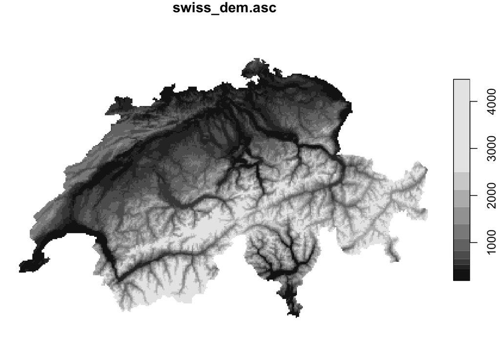

```r
swiss.dem <- read_stars("../datafiles/swiss_ppt//swiss_dem.asc")
st_crs(swiss.dem) <- 2056
plot(swiss.dem)
```

And finally, we’ll load the shapefile of country borders (*ne_50m_admin_0_countries.shp*) and extract only the border of Switzerland:

```r
countries <- st_read("../datafiles/ne_50m_admin_0_countries/ne_50m_admin_0_countries.shp")
swiss.bord <- subset(countries, NAME == "Switzerland")
swiss.bord <- st_transform(swiss.bord, 2056)
```

And finally, we’ll plot the data and country outline:

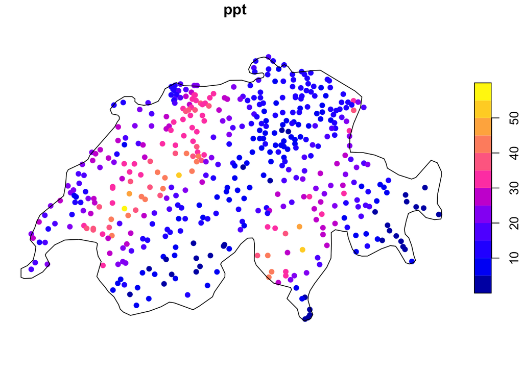

```r
plot(swiss.sf["ppt"], reset = FALSE, pch = 16)
plot(st_geometry(swiss.bord), add = TRUE)
```

Or alternatively, we can plot with **ggplot2**:

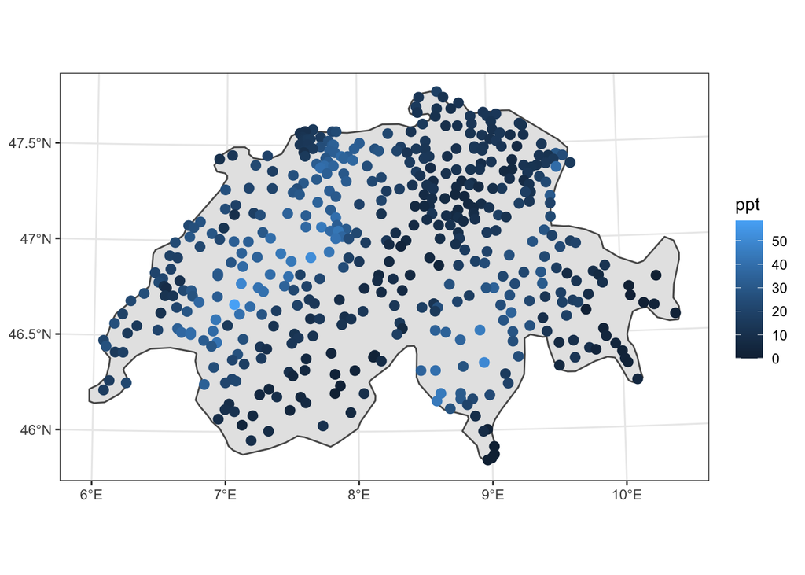

```r
library(ggplot2)
ggplot() +
  geom_sf(data = swiss.bord) +
  geom_sf(data = swiss.sf, aes(col = ppt), size = 2.5) +
  theme_bw()
```

## Meuse soil sample dataset

Now load the Meuse datasets. Here, we’ll just load the points data from a shapefile (*meuse.shp*) and a shapefile of the river for plotting (*meuseriv.shp*).

```r
meuse <- st_read("../datafiles/meuse/meuse.shp")
meuseriv <- st_read("../datafiles/meuse/meuseriv.shp")
```

# Variogram analysis

We will first use the Meuse dataset as an example of how to perform variogram analysis. Start by making a simple plot of the zinc concentrations using the `plot()` function:

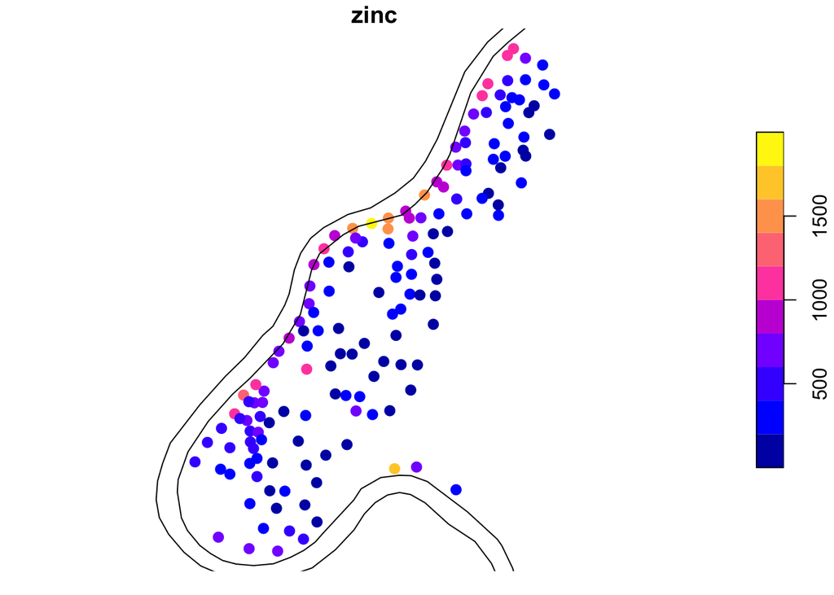

```r
plot(meuse["zinc"], pch = 16, cex = 1.25, reset = FALSE)
plot(meuseriv, add = TRUE, col = NA)
```

Note that plotting the histogram of zinc values suggest that they are right skewed with a few high values. Check this by plotting a histogram of the values.

```r
hist(meuse$zinc)
```

```r
hist(meuse$zinc)
meuse$lzinc <- log(meuse$zinc)
plot(meuse["zinc"], pch = 16, cex = 1.25, reset = FALSE)
plot(meuseriv, add = TRUE, col = NA)
```

## Sample variogram

We will now use the `variogram()` function to build a sample variogram for the log-transformed data. We start here by loading the **gstat** library, then build the sample variogram. This uses the usual R model syntax, which we will later use to include covariates. Here we simply use the formula `lzinc ~ 1`, which indicates that we are assuming the mean log zinc value does not vary across our region. Finally we plot the variogram, adding an argument to show the number of pairs of points used to calculate each point:

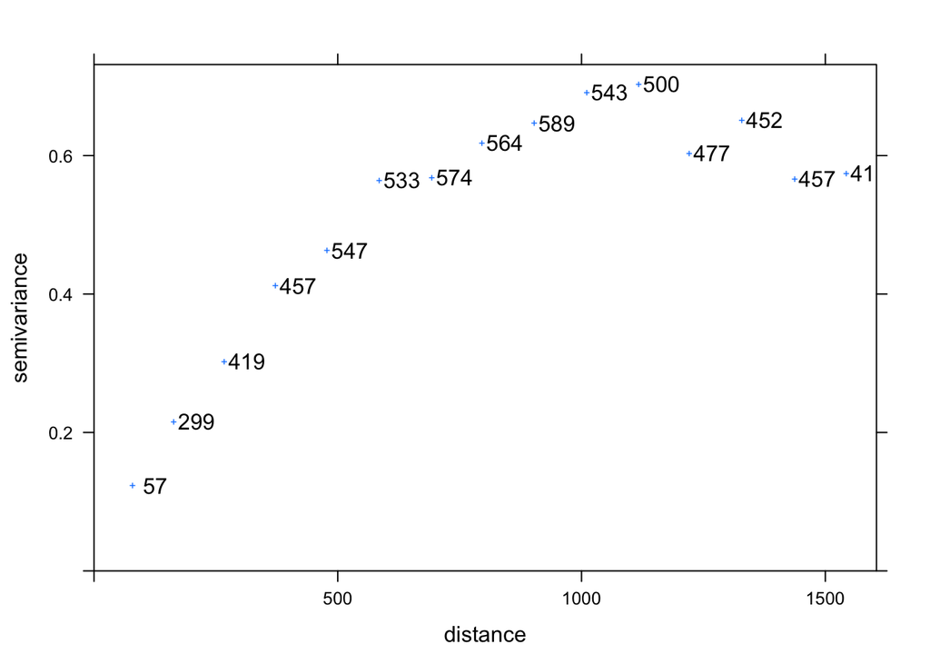

```r
library(gstat)
mzinc.var <- variogram(lzinc ~ 1, meuse)
plot(mzinc.var, plot.numbers = TRUE, pch = '+')
```

We can specify the number of lags to be included by using two parameters, which allows us to search for spatial dependence over a larger or smaller range of distances. The first of these, `cutoff`, specifies the maximum distance over which we will consider pairwise differences between points. The second, `width`, specifies the size of each lag. Try experimenting with these parameters to obtain the optimal variogram.

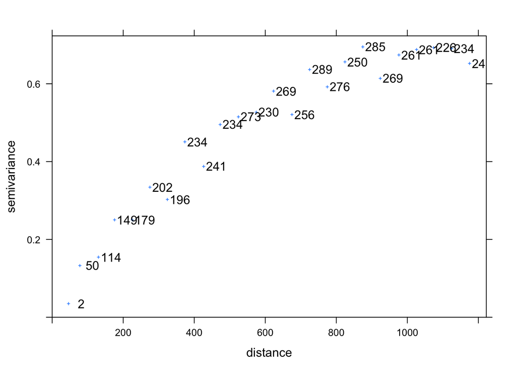

```r
mzinc.var2 <- variogram(lzinc ~ 1, meuse, cutoff = 1200, width = 50)
plot(mzinc.var2, plot.numbers = TRUE, pch = '+')
```

Now use the `variogram()` function to build a sample variogram for the Swiss precipitation data.

```r
ppt.var <- variogram(ppt ~ 1, swiss.sf)
```

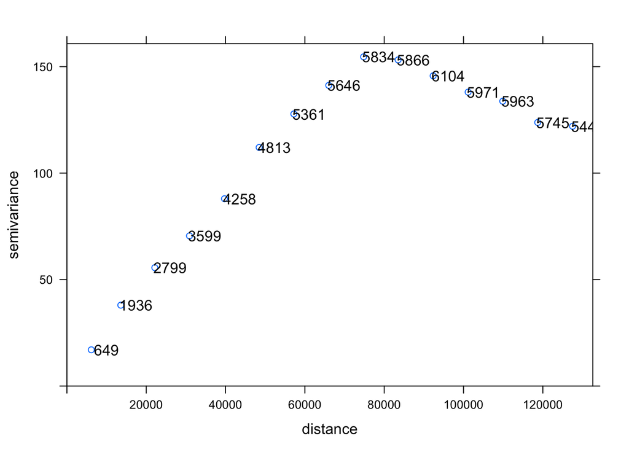

```r
plot(ppt.var, plot.numbers = TRUE)
```

## Variogram modeling

Having made the sample variogram, we now fit a variogram model to this. There are a set of standard parametric models that are used. To see the ones available in **gstat**, type:

```r
vgm()
```

```
##    short
## 1    Nug
## 2    Exp
## 3    Sph
## 4    Gau
## 5    Exc
## 6    Mat
## 7    Ste
## 8    Cir
## 9    Lin
## 10   Bes
## 11   Pen
## 12   Per
## 13   Wav
## 14   Hol
```

[output cut: 27 more lines]

To fit a model, it is necessary to create a first model by hand, then use the `fit.variogram()` function, which uses a weighted least squares method to fit this to the sample variogram. The first model requires you to specify:

- the model form
- the value of the nugget (the intercept with the Y axis)
- the model range (the distance at which the sample variogram becomes flat)
- the sill, the semivariance value (y-axis) of the range

Here we specify these as separate variables, then use the `vgm()` function to build the initial model. As in the previous section, we will start by doing this for the Meuse dataset. Some suggested values are given in the code below, but it is worth replotting the original variogram, to see how these values compare to the sample variable.

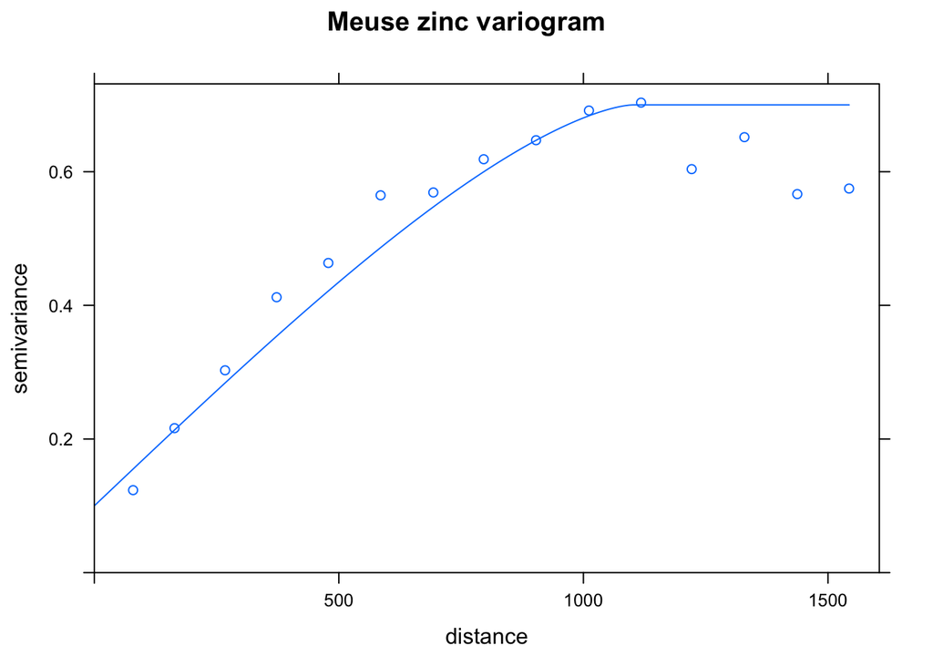

```r
modNugget <- 0.1
modRange <- 1100
modSill <- 0.6
mzinc.vgm1 <- vgm(psill = modSill, "Cir", range = modRange, nugget = modNugget)
plot(mzinc.var, mzinc.vgm1, main = "Meuse zinc variogram")
```

The model only fits approximately to the sample variogram, so we can now use an iterative weighted OLS method (`fit.variogram()`) to fit the model variogram to the sample variogram.

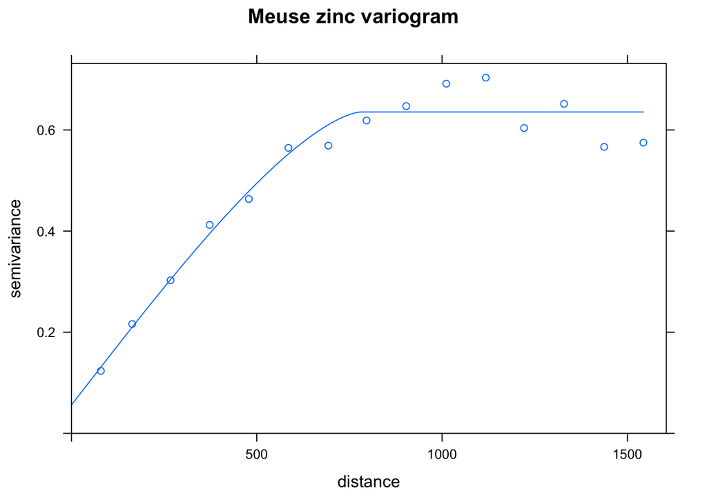

```r
mzinc.vgm2 <- fit.variogram(mzinc.var, mzinc.vgm1)
plot(mzinc.var, mzinc.vgm2, main = "Meuse zinc variogram")
```

You can see the final fitted parameters of the variogram by typing the name of the fitted model object:

```r
mzinc.vgm2
```

```
##   model      psill    range
## 1   Nug 0.05605498   0.0000
## 2   Cir 0.57945087 779.3562
```

The fitting routine is generally fairly robust and will fit an initial model that may be somewhat different from the sample variogram, but it is always worth plotting the new model to be sure. Try remaking and fitting the initial model, using, for example, the spherical model.

Now follow the same steps to obtain a variogram model for the precipitation data. Remember to start by plotting the sample variogram in the previous step to visually estimate the three parameters needed.

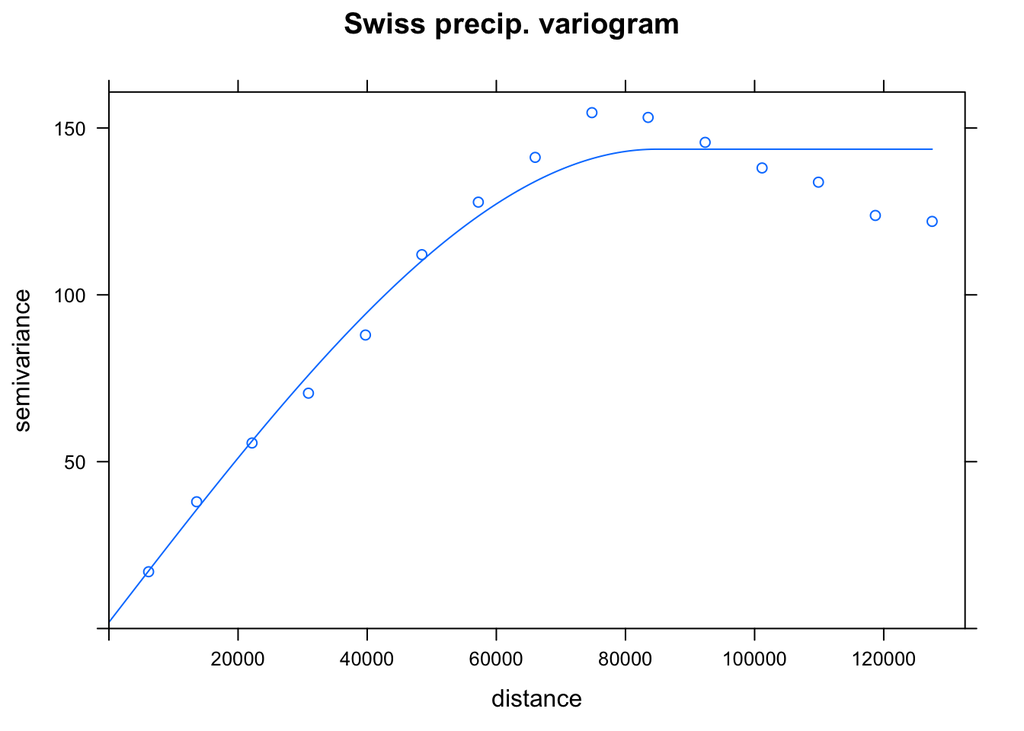

```r
modNugget <- 10
modRange <- 75000
modSill <- 140
ppt.vgm1 <- vgm(psill = modSill, "Sph", range = modRange, nugget = modNugget)
ppt.vgm2 <- fit.variogram(ppt.var, ppt.vgm1)
plot(ppt.var, ppt.vgm2, main = "Swiss precip. variogram")
```

# Spatial prediction

## Ordinary Kriging

We now use our fitted model to predict precipitation values across Switzerland. The `krige()` function performs spatial prediction, using ordinary kriging as a default. This requires a set of input:

- A model formula specifying the variable to be predicted (this can be extended to include covariates as we will see)
- The Spatial* object with the observed values
- A Spatial* object with the coordinates to be used for prediction
- The fitted variogram model
- An optional parameter that limits the number of points to be used in predicting any given location

See `?krige` for other parameters.

```r
ppt.pred.ok <- krige(ppt ~ 1, swiss.sf, swiss.dem, ppt.vgm2, nmax = 40)
```

### Plotting the results

```r
names(ppt.pred.ok)
```

To see the predicted values, we can simply plot the first of these:

```r
plot(ppt.pred.ok, main = "Interpolated precipitation values (OK)")
```

We can add some color to this image using a couple of add-on packages (you’ll need to install these if you haven’t already). Here’s an example using one of the **viridis** [palettes](https://github.com/sjmgarnier/viridis):

```r
library(viridis)
```

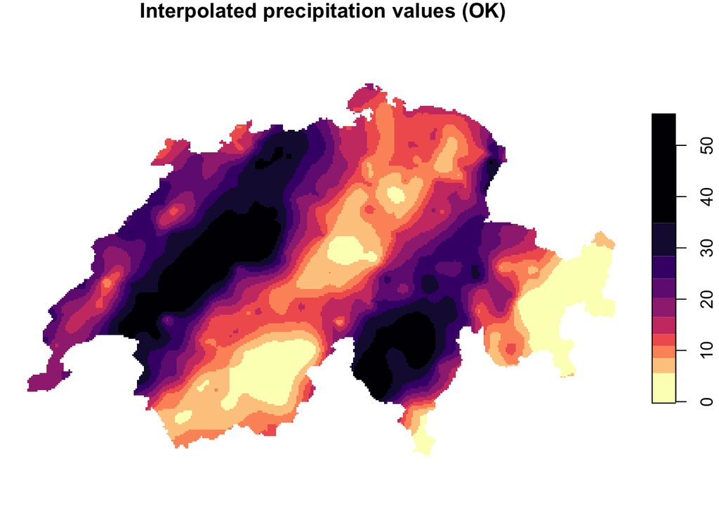

```r
nbreaks <- 11
my.pal <- rev(magma(10))
plot(ppt.pred.ok, col = my.pal,
     main = "Interpolated precipitation values (OK)")
```

And here’s an example using the [RColorBrewer](https://colorbrewer2.org/) package (use the `display.brewer.all()` function to see the full set of palettes):

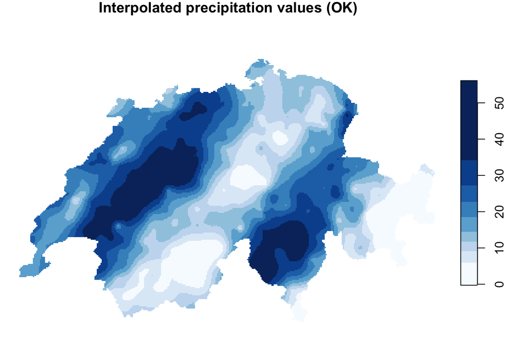

```r
library(RColorBrewer)
my.pal <- brewer.pal(9, "Blues")
plot(ppt.pred.ok, col = my.pal,
     main = "Interpolated precipitation values (OK)")
```

And we can equally plot the prediction errors:

```r
plot(ppt.pred.ok["var1.var"],
     main = "Interpolated precipitation prediction error (OK)")
```

## Assessing model quality

To assess the performance of our kriging model, we use a $n$-fold cross-validation (also called $k$-fold). This splits the data into $n$ subsets, then iteratively predicts each subset from the other $n-1$ sets. The `krige.cv()` function performs the cross-validation: this takes the same arguments as the `krige()` function, but we leave out the object with coordinates for new predictions, and specify `nfold`, the number of subsets to be used. You will see some warnings about the projection. You can safely ignore these.

```r
ppt.cv.ok <- krige.cv(ppt ~ 1, swiss.sf, ppt.vgm2, nmax = 40, nfold = 5)
head(ppt.cv.ok)
```

The output of this function is a spatial object with the following variables:

- `var1.pred`: the cross-validated prediction at the site (when it is in the test set)
- `var1.var`: the cross-validated prediction error at the site
- `observed`: the observed value at the site
- `residual`: the difference between the predicted and observed value
- `z-score`: a $z$-score calculated as the residual divided by the error
- `fold`: the ‘fold’ or iteration when the site was in the test set

We can calculate two statistics from this: the root mean squared error of prediction (RMSEP) and the R$^2_P$ of prediction:

```r
## RMSEP
sqrt(mean(ppt.cv.ok$residual^2))
##R2P
cor(ppt.cv.ok$observed, ppt.cv.ok$var1.pred)^2
```

The first of these (RMSEP) gives the average error that might be expected when making a prediction, the second (R$^2_P$) gives the amount of variance in the test dataset predicted by the model.

The output of `krige.cv()` contains, for each observation, the predicted value when that location was omitted from the model, the S.E., the observed value and the residual (predicted - observed). We can use the `bubble()` function to plot these, which shows both the size and the direction of the residual. Note that to use this we need to convert the `sf` object to the older `sp` class by using the `as_Spatial()` function:

```r
sp::bubble(as_Spatial(ppt.cv.ok)[,"residual"], pch = 16)
```

```r
plot(ppt.cv.ok$var1.pred, ppt.cv.ok$residual,
     xlab = 'PPT Predicted Values', ylab = 'PPT Residuals')
abline(h = 0,lty = 2)
```

# Exercise

1. The compressed file *oregon.zip* contains data on average annual temperatures for Oregon from a set of climate stations in the shapefile `oregontann.shp` in a variable called ‘tann’, and station elevation in a variable called `elevation`. A second file *orgrid.shp* contains a set of gridded elevations for the state at 10 minute resolution. Code is given below to read in these data and convert to `sf` and `stars` objects for geostatistical analysis. Using the **gstat** library, carry out the following analyses:
- Read in the files and produce a sample variogram for average annual temperatures in Oregon. (Use the `variogram()` function)
- Create a variogram model for this data using the `vgm()` function. You will need to choose an appropriate model and initial parameters for the nugget, sill and range. Report the values and model you have used
- Use the `fit.variogram()` function to fit this model to the sample variogram from step a. Produce a plot showing the final variogram
- Now use this model to interpolate the annual temperatures using the grid from the DEM, using the `krige()` function. Produce a map showing the predicted value on the grid and the prediction error.
- Use the `krige.cv()` function with 5-fold cross-validation to report the root mean squared error and R$^2$

This is the code to read in and convert all the necessary data to `sf` and `starts` objects. Note that we have to assign the CRS to each object. The data are in unprojected longitude/latitude, so we use the WGS84 description (EPSG code 4326). The gridded elevation is in an odd format: point data into a shapefile. Here we use `st_rasterize()` to force this into a full grid for interpolation.

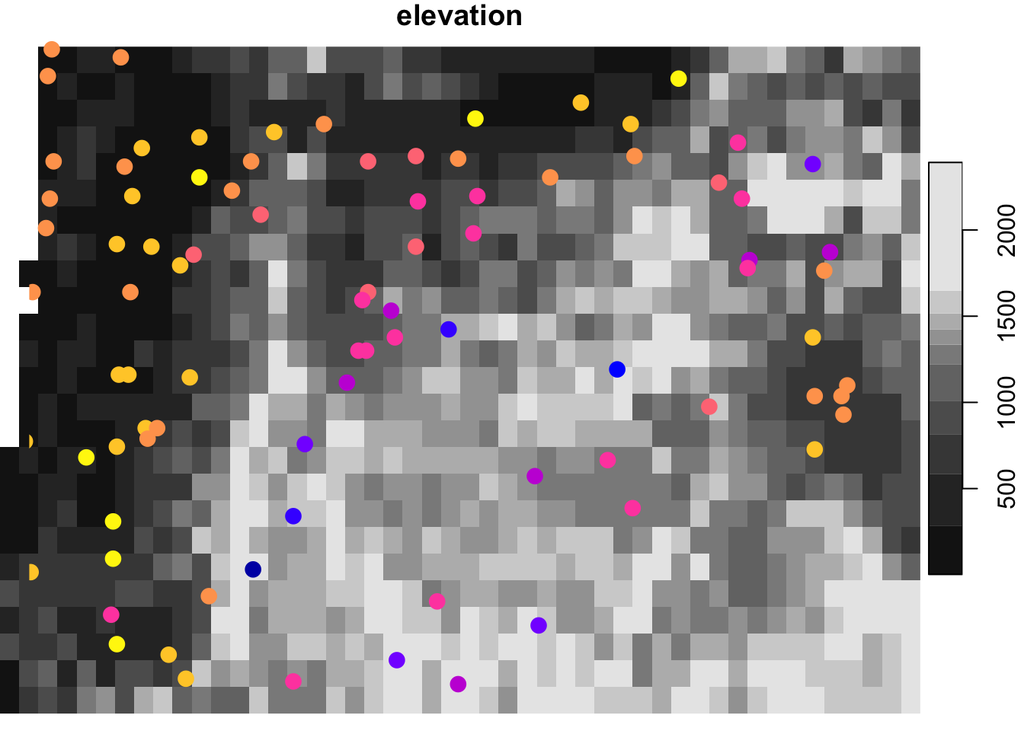

```r
# Oregon boundaries
orotl <- st_read("../datafiles/oregon/orotl.shp")
st_crs(orotl) <- 4326
# Oregon temperatures
ortann <- st_read("../datafiles/oregon/oregontann.shp")
st_crs(ortann) <- 4326
# Oregon DEM file
orgrid <- st_read("../datafiles/oregon/orgrid.shp")
st_crs(orgrid) <- 4326
orgrid.dem <- st_rasterize(orgrid, dx = 0.1667, dy = 0.1667)
plot(orgrid.dem, reset = FALSE)
plot(ortann["tann"], add = TRUE, pch = 16, cex = 1.5)
```

# File details

## Swiss precipitation: *swiss_ppt.csv*

## Meuse soil samples: *meuse.shp*

## Oregon annual temperature: *ortann.shp*